# Flexible Damage Functions

Author

James Rising, Sebastian Cadavid Sanchez, Climate Impact Lab

Published

April 30, 2026

## 0.1 Energy: Total Country Unconstrained

Flexible damage function parameters at the Country level.

**Outcome units:** `kWh_per_capita` — kWh per capita for total, rebased to 2005 baseline; DIAGNOSTIC variant with NO beta constraint applied (allows beta < 0 = concave temperature response). Compare with the constrained total_country version to see where the convexity constraint is binding and how it shifts the regional fit.

$$D_{it} = (\alpha_i T_t + \beta_i T_t^2) \cdot Y_{it}^{\gamma}$$

where $\gamma$ is the income elasticity (fitted globally), $\alpha_i$ is the linear coefficient, and $\beta_i$ is the quadratic coefficient.

# 1 Global Estimation

## 1.1 Income Elasticity Estimation

The income elasticity $\gamma$ is estimated using a fixed-effects regression:

$$y_{it} = \gamma \cdot \log(Y_{it}) + \mu_{g(i,T)} + \nu_t + \varepsilon_{it}$$

where $\mu_{g(i,T)}$ are region-by-temperature-bin fixed effects and $\nu_t$ are year fixed effects.

Table 1: Income Elasticity (Gamma) Estimation Results

| Statistic | Value |
| --- | --- |
| Income elasticity ($\gamma$) | 0.0659 |
| Standard error | 1.46e-02 |
| 95% CI | [0.0374, 0.0945] |
| R-squared | 0.9084 |
| Observations | 3,519,180 |
| Regions | 245 |
| Gamma quantiles | 19 |

# 2 Parameter Distributions

## 2.1 8-Panel Summary

Row 1: gamma, alpha, beta, rsqr1. Row 2: rho, zeta, eta, rsqr2.

```
Using median gamma: 0.065944, 245 rows (of 4,655 total)
```

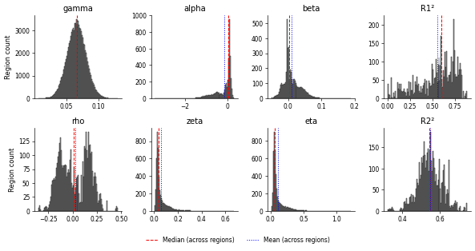

Figure 1: Distribution of Regional Parameters

## 2.2 Projection Equation and Parameter Definitions

The estimated parameters are used to project damages via Monte Carlo sampling:

$$D_{it}^k = (\hat{\alpha}_{ik} T_t + \hat{\beta}_{ik} T_t^2) Y_{it}^{\hat{\gamma}_k} + \hat{\theta}_{ik} T_t Y_{it}^{\hat{\gamma}_k} + \hat{\phi}_{it}^k$$

where $k$ indexes the Monte Carlo draw. The parameters in each row of the output CSV control distinct components of this equation:

- **gamma**: income elasticity $\hat{\gamma}_k$, one of 19 quantile values drawn from $N(\hat{\gamma}, SE(\hat{\gamma}))$
- **alpha, beta**: linear and quadratic temperature coefficients; $\hat{\alpha}_{ik}$ and $\hat{\beta}_{ik}$ are drawn from the joint normal defined by the VCV below
- **sigma11, sigma12, sigma22**: variance-covariance matrix of $(\alpha, \beta)$, used for joint uncertainty sampling
- **rho**: correlation between regional and global polynomial residuals $\rho_i$, used to maintain spatial covariance across regions in Monte Carlo draws
- **zeta**: temperature-dependent error scale $\zeta_{ik}$; the run-specific error term $\hat{\theta}_{ik}$ is drawn from $N(0, \zeta_{ik})$
- **eta**: residual noise standard deviation $\eta_{ik}$; the annual noise $\hat{\phi}_{it}^k$ is drawn from $N(0, \eta_{ik})$
- **rsqr1, rsqr2**: polynomial fit quality and error model fit, respectively

## 2.3 Summary Statistics

Table 2: Regional Parameter Summary

| Parameter | Mean | Median | Std | Min | Max | N |
| --- | --- | --- | --- | --- | --- | --- |
| alpha | -0.161 | 0.05301 | 0.4229 | -2.674 | 0.235 | 245 |
| beta | 0.01022 | 0.003429 | 0.02589 | -0.04062 | 0.1522 | 245 |
| rho | 0.02431 | 0.01166 | 0.1533 | -0.3405 | 0.4524 | 245 |
| zeta | 0.05992 | 0.03743 | 0.05818 | 0.009076 | 0.5209 | 245 |
| eta | 0.1107 | 0.06665 | 0.11 | 0.01697 | 0.9411 | 245 |
| rsqr1 | 0.5518 | 0.5966 | 0.2115 | 0.005605 | 0.8839 | 245 |
| rsqr2 | 0.5477 | 0.5448 | 0.06525 | 0.3349 | 0.7424 | 245 |

# 3 Spaghetti Curves

Regional damage function curves showing D(T) = αT + βT² for sampled regions.

[interactive chart not shown]

Figure 2: Regional Damage Functions

# 4 Zero Crossings

The zero crossing (extremum) of the parabola occurs at $T^* = -\alpha / (2\beta)$.

Table 3: Zero Crossing Statistics

| Category | Count | Percentage |
| --- | --- | --- |
| β = 0 (no crossing) | 0 | 0.0% |
| T > 20°C (beyond graph) | 27 | 11.0% |
| T < 0°C (negative crossing) | 45 | 18.4% |
| Valid crossings (0-20°C) | 173 | 70.6% |

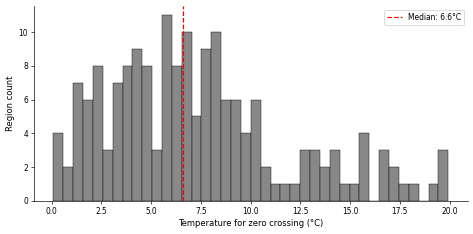

Figure 3: Distribution of Zero Crossing Temperatures

# 5 Slope Analysis

Maximum slope between 0 and 10°C: $\frac{dM}{dT} = \alpha + 2\beta T$

The maximum occurs at either T=0 or T=10 (endpoints of interval).

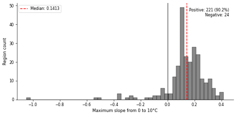

Figure 4: Distribution of Maximum Slopes (0-10°C)

# 6 Convexity Analysis

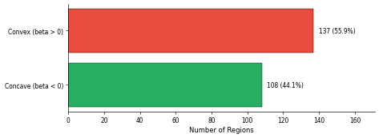

Figure 5: Beta Sign Distribution (Convexity)

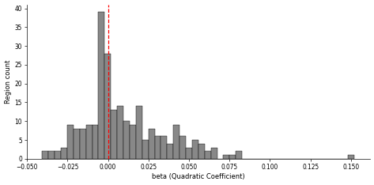

Figure 6: Beta Distribution

## 6.1 Convexity by Country

Table 4: Fraction of Convex (beta > 0) Regions by Country (top 20)

| country | n_regions | n_convex | frac_convex |
| --- | --- | --- | --- |
| ALA | 1 | 1 | 100.0% |
| ALB | 1 | 1 | 100.0% |
| AND | 1 | 1 | 100.0% |
| ARG | 1 | 1 | 100.0% |
| ARM | 1 | 1 | 100.0% |
| ASM | 1 | 1 | 100.0% |
| AUS | 1 | 1 | 100.0% |
| AUT | 1 | 1 | 100.0% |
| AZE | 1 | 1 | 100.0% |
| BDI | 1 | 1 | 100.0% |
| BEL | 1 | 1 | 100.0% |
| BGR | 1 | 1 | 100.0% |
| BHS | 1 | 1 | 100.0% |
| BIH | 1 | 1 | 100.0% |
| BLM | 1 | 1 | 100.0% |
| BLR | 1 | 1 | 100.0% |
| BMU | 1 | 1 | 100.0% |
| BOL | 1 | 1 | 100.0% |
| BRN | 1 | 1 | 100.0% |
| BTN | 1 | 1 | 100.0% |

# 7 R-squared Analysis

## 7.1 Polynomial Fit Quality (rsqr1)

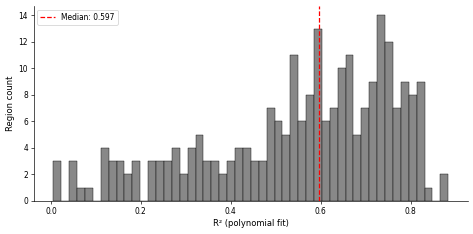

Figure 7: Regional Fit Quality (R-squared)

## 7.2 Error Model R-squared (rsqr2) Quantiles

Table 5: rsqr2 Quantiles

| 0% (Min) | 25% | 50% (Median) | 75% | 100% (Max) |
| --- | --- | --- | --- | --- |
| 0.3349 | 0.5073 | 0.5448 | 0.5929 | 0.7424 |

# 8 Modelled Variance

Modelled variance statistic: $1 - \frac{\sum_i \eta_i^2}{\sum_i D_i^2}$

Table 6: Modelled Variance Statistics

| Statistic | Value |
| --- | --- |
| Modelled variance | 0.9812 |
| Sum(η²) | 5.9559 |
| Sum(D²) at T=3.0°C | 316.0486 |
| N regions | 245 |

# 9 Best- and Worst-Fitting Regions

The 3 worst- and 3 best-fitting regions by R-squared, with raw simulation data overlaid on the fitted polynomial curve. **Red rows = worst fits**, **green rows = best fits**.

Table 7: Best- and worst-fitting regions

Top 3 best fit (R²) Top 3 worst fit (R²)

| Region | α | β | η | R² |
| --- | --- | --- | --- | --- |
| AND | -0.992 | 0.0318 | 0.214 | 0.884 |
| LIE | -0.964 | 0.0343 | 0.224 | 0.869 |
| RUS | -1.25 | 0.0569 | 0.305 | 0.846 |
| NGA | 0.0191 | -0.00506 | 0.0708 | 0.00561 |
| YEM | -0.0129 | 0.00435 | 0.0749 | 0.00902 |
| GUY | 0.0396 | -0.00627 | 0.0629 | 0.0219 |

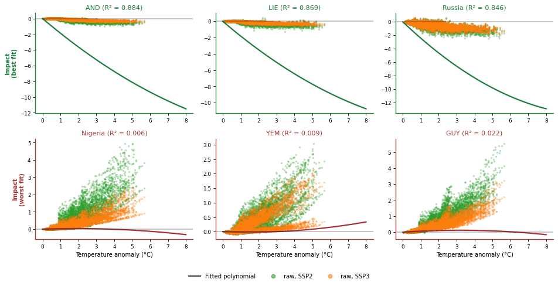

# 10 Regional Parameter Maps

Maps of key parameters at the **country** level. Red = negative (damage increases with T), Blue = positive.

## 10.1 Alpha (Linear Coefficient)

Alpha ($\alpha$) represents the linear sensitivity to temperature. Regions with negative alpha experience damage that increases with the first degree of warming.

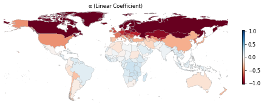

Figure 9: α (linear coefficient)

## 10.2 Beta (Quadratic Coefficient)

Beta ($\beta$) represents the curvature of the damage function.

The **no constraint applied** (β unconstrained) constraint is enforced for this sector, meaning this is an unconstrained diagnostic run. β can take either sign, letting the data choose convex or concave shape per region..

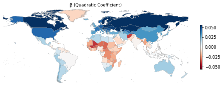

Figure 10: β (quadratic coefficient)

## 10.3 R-squared (Fit Quality)

$R^2$ measures the polynomial fit quality. Higher values indicate that the quadratic form captures more of the variance in the data.

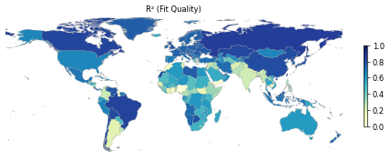

Figure 11: R² (stage 1 fit quality)

# 11 F2: Flex vs Raw Comparison

Comparison of flexible damage function predictions against raw simulation means.

For each scenario (RCP × SSP × Model), we compute at the final year:

- **Flex predicted**: $(\alpha \cdot T + \beta \cdot T^2) \cdot Y^\gamma$
- **Raw actual**: The outcome variable (y) from the source data

**Year 2099**: 65,780 rows

**rcp45**

**SSP2**

**high**

**Correlation:** 0.8531 | **RMSE:** 1.685973 | **Sign agreement:** 69.0%

[interactive chart not shown]

Top 5 best predicted Top 5 worst predicted

Year 2099 · T<sub>mean</sub> across these regions: 1.96°C

| Region | Raw | Flex | Residual |
| --- | --- | --- | --- |
| ETH | 0.495 | 0.517 | 0.0221 |
| ZWE | 0.707 | 0.684 | -0.0232 |
| KEN | 0.528 | 0.62 | 0.0915 |
| UGA | 0.776 | 0.683 | -0.0931 |
| MWI | 0.871 | 0.775 | -0.0961 |
| SJM | -3.14 | -9.69 | -6.55 |
| FIN | -1.11 | -6.11 | -5 |
| EST | -0.846 | -5.14 | -4.3 |
| CAN | -0.656 | -4.71 | -4.06 |
| SWE | -0.61 | -4.66 | -4.05 |

**low**

**Correlation:** 0.7894 | **RMSE:** 1.616920 | **Sign agreement:** 68.6%

[interactive chart not shown]

Top 5 best predicted Top 5 worst predicted

Year 2099 · T<sub>mean</sub> across these regions: 1.96°C

| Region | Raw | Flex | Residual |
| --- | --- | --- | --- |
| SLE | 0.44 | 0.421 | -0.0183 |
| LBR | 0.444 | 0.463 | 0.0192 |
| NPL | 0.317 | 0.358 | 0.0415 |
| CAF | 0.395 | 0.442 | 0.0465 |
| GIN | 0.338 | 0.438 | 0.1 |
| SJM | -2.28 | -9.42 | -7.13 |
| FIN | -1.08 | -6.08 | -5.01 |
| EST | -0.601 | -4.92 | -4.32 |
| SWE | -0.673 | -4.73 | -4.06 |
| CAN | -0.668 | -4.72 | -4.05 |

**SSP3**

**high**

**Correlation:** 0.7631 | **RMSE:** 1.555886 | **Sign agreement:** 69.0%

[interactive chart not shown]

Top 5 best predicted Top 5 worst predicted

Year 2099 · T<sub>mean</sub> across these regions: 1.96°C

| Region | Raw | Flex | Residual |
| --- | --- | --- | --- |
| CPV | 0.342 | 0.324 | -0.0178 |
| SWZ | 0.278 | 0.301 | 0.0226 |
| HTI | 0.385 | 0.41 | 0.0248 |
| TON | 0.223 | 0.248 | 0.0249 |
| BGD | 0.475 | 0.423 | -0.0513 |
| SJM | -1.68 | -9.23 | -7.55 |
| FIN | -0.964 | -6 | -5.03 |
| EST | -0.729 | -5.03 | -4.3 |
| CAN | -0.672 | -4.73 | -4.05 |
| SWE | -0.534 | -4.57 | -4.04 |

**low**

**Correlation:** 0.6771 | **RMSE:** 1.561309 | **Sign agreement:** 69.8%

[interactive chart not shown]

Top 5 best predicted Top 5 worst predicted

Year 2099 · T<sub>mean</sub> across these regions: 1.96°C

| Region | Raw | Flex | Residual |
| --- | --- | --- | --- |
| LKA | 0.276 | 0.275 | -8.89e-4 |
| TLS | 0.347 | 0.349 | 0.00171 |
| BLM | 0.43 | 0.433 | 0.00354 |
| COK | 0.16 | 0.155 | -0.00508 |
| NIC | 0.285 | 0.297 | 0.0112 |
| SJM | -0.907 | -9 | -8.1 |
| FIN | -0.948 | -5.99 | -5.04 |
| EST | -0.532 | -4.86 | -4.33 |
| CAN | -0.566 | -4.62 | -4.06 |
| SWE | -0.518 | -4.56 | -4.04 |

**rcp85**

**SSP2**

**high**

**Correlation:** 0.8057 | **RMSE:** 3.635841 | **Sign agreement:** 66.9%

[interactive chart not shown]

Top 5 best predicted Top 5 worst predicted

Year 2099 · T<sub>mean</sub> across these regions: 4.20°C

| Region | Raw | Flex | Residual |
| --- | --- | --- | --- |
| ERI | 0.85 | 0.741 | -0.109 |
| RWA | 1.34 | 1.18 | -0.155 |
| BDI | 1.72 | 1.52 | -0.205 |
| MDG | 1.35 | 1.03 | -0.32 |
| CCK | 1.38 | 0.821 | -0.559 |
| SJM | -5.13 | -17.8 | -12.7 |
| FIN | -1.66 | -11.5 | -9.8 |
| EST | -1.15 | -9.41 | -8.27 |
| NOR | -1.09 | -9.22 | -8.13 |
| CAN | -0.581 | -8.54 | -7.96 |

**low**

**Correlation:** 0.7229 | **RMSE:** 3.363330 | **Sign agreement:** 66.9%

[interactive chart not shown]

Top 5 best predicted Top 5 worst predicted

Year 2099 · T<sub>mean</sub> across these regions: 4.20°C

| Region | Raw | Flex | Residual |
| --- | --- | --- | --- |
| KEN | 0.958 | 0.968 | 0.0103 |
| COM | 0.748 | 0.761 | 0.0135 |
| GIN | 0.76 | 0.625 | -0.134 |
| ERI | 0.957 | 0.74 | -0.217 |
| MOZ | 1 | 0.75 | -0.25 |
| SJM | -3.73 | -17.3 | -13.6 |
| FIN | -1.61 | -11.4 | -9.79 |
| EST | -0.824 | -9.01 | -8.19 |
| NOR | -1.19 | -9.35 | -8.16 |
| CAN | -0.592 | -8.55 | -7.96 |

**SSP3**

**high**

**Correlation:** 0.6981 | **RMSE:** 3.168916 | **Sign agreement:** 66.1%

[interactive chart not shown]

Top 5 best predicted Top 5 worst predicted

Year 2099 · T<sub>mean</sub> across these regions: 4.20°C

| Region | Raw | Flex | Residual |
| --- | --- | --- | --- |
| NPL | 0.363 | 0.358 | -0.00473 |
| TON | 0.668 | 0.658 | -0.00945 |
| TLS | 0.684 | 0.718 | 0.0342 |
| ZMB | 1.14 | 1.17 | 0.0346 |
| COD | 0.796 | 0.848 | 0.0527 |
| SJM | -2.74 | -17 | -14.2 |
| FIN | -1.45 | -11.2 | -9.79 |
| EST | -0.991 | -9.21 | -8.22 |
| NOR | -0.964 | -9.05 | -8.09 |
| CAN | -0.584 | -8.57 | -7.98 |

**low**

**Correlation:** 0.5906 | **RMSE:** 3.153362 | **Sign agreement:** 66.5%

[interactive chart not shown]

Top 5 best predicted Top 5 worst predicted

Year 2099 · T<sub>mean</sub> across these regions: 4.20°C

| Region | Raw | Flex | Residual |
| --- | --- | --- | --- |
| CXR | 0.407 | 0.392 | -0.0149 |
| NPL | 0.314 | 0.333 | 0.0183 |
| MOZ | 0.636 | 0.664 | 0.0283 |
| COD | 0.786 | 0.822 | 0.0362 |
| MUS | 0.882 | 0.843 | -0.0388 |
| SJM | -1.48 | -16.6 | -15.1 |
| FIN | -1.43 | -11.2 | -9.8 |
| EST | -0.732 | -8.9 | -8.17 |
| NOR | -1.07 | -9.18 | -8.12 |
| GRL | -0.861 | -8.96 | -8.1 |

## 11.1 Scenario Summary

| RCP | SSP | Model | N | Corr | RMSE | Sign% |
| --- | --- | --- | --- | --- | --- | --- |
| rcp45 | SSP2 | high | 245 | 0.8531 | 1.68597 | 69.0% |
| rcp45 | SSP2 | low | 245 | 0.7894 | 1.61692 | 68.6% |
| rcp45 | SSP3 | high | 245 | 0.7631 | 1.55589 | 69.0% |
| rcp45 | SSP3 | low | 245 | 0.6771 | 1.56131 | 69.8% |
| rcp85 | SSP2 | high | 245 | 0.8057 | 3.63584 | 66.9% |
| rcp85 | SSP2 | low | 245 | 0.7229 | 3.36333 | 66.9% |
| rcp85 | SSP3 | high | 245 | 0.6981 | 3.16892 | 66.1% |
| rcp85 | SSP3 | low | 245 | 0.5906 | 3.15336 | 66.5% |

# 12 Data Reference

## 12.1 File Locations

| Item | Path |
| --- | --- |
| Regional CSV | `/project/cil/gcp/flex_damage_funcs/parameters/energy__total_country_unconstrained__regional_parameters.csv` |
| Global JSON | `/project/cil/gcp/flex_damage_funcs/parameters/energy__total_country_unconstrained__global_results.json` |
| Metadata JSON | `/project/cil/gcp/flex_damage_funcs/parameters/energy__total_country_unconstrained__metadata.json` |

## 12.2 Column Definitions

| Column | Description |
| --- | --- |
| `region` | Region identifier (hierarchical code, first 3 chars = country ISO3) |
| `gamma` | Income elasticity quantile value |
| `alpha` | Linear temperature coefficient |
| `beta` | Quadratic temperature coefficient |
| `sigma11` | Var(alpha) |
| `sigma12` | Cov(alpha, beta) |
| `sigma22` | Var(beta) |
| `rho` | Correlation with global residual process |
| `zeta` | Temperature-dependent heteroskedasticity |
| `eta` | Residual standard deviation |
| `rsqr1` | R-squared of polynomial fit |
| `rsqr2` | R-squared of error model |

*Report generated with FlexDamage v1.0.0*